# EDUC 423A/SOC 302A: Assignment 1

Lucy Caffrey-Maffei

10/6/2021

# Honor Code Statement

We strongly encourage students to form study groups and students may discuss and work on assignments in groups. We expect that each student understands their own submission. As such, students must write their submissions independently and clearly disclose the names of all other students who were part of their study group. Additionally, lifting code or solutions directly from the internet (e.g., Google, GitHub, Stack Overflow) is a violation of the [Stanford Honor Code](https://communitystandards.stanford.edu/policies-and-guidance/honor-code). We take academic honesty and Honor Code violations extremely seriously and expect the same of students. If you have questions about what may or may not constitute an Honor Code violation, please reach out the teaching team.

**Email: l.caffreymaffei@stanford.edu**

**SUID: lacm23/06527423**

**Study Group:** Laura Hinton

I acknowledge and agree to abide by the Honor Code.

**Signed: Lucy Caffrey-Maffei, October 6, 2021**

# Setup

```r
# Include all code required to load packages and import data here.
# The echo=TRUE flag ensures that the code will appear in your submission.

library(gganimate)
library(gifski)
library(tidyverse)
hwone <- read_csv("EDUC423A_HSL.csv")
```

# Univariate Plot

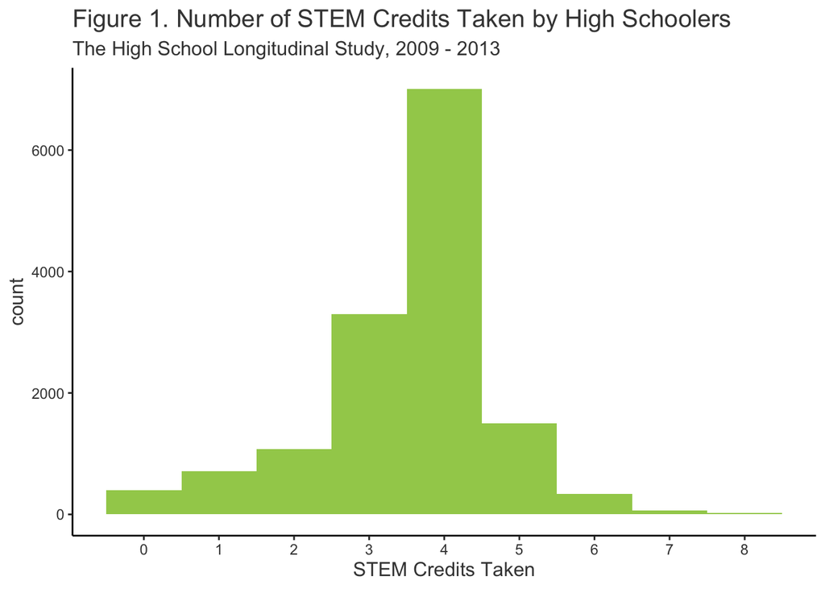

```r
# Include all code required to generate your visualization here.

ggplot(hwone) +
  geom_histogram(aes( x = credits_stem), binwidth = 1, fill ='darkolivegreen3') +
  labs(x = "STEM Credits Taken", title = "Figure 1. Number of STEM Credits Taken by High Schoolers", subtitle = "The High School Longitudinal Study, 2009 - 2013") +
  scale_x_continuous(breaks = 0:8) +
  theme_classic()+
  theme(axis.text.x = element_text(color = "gray26", size = 9),
        plot.title = element_text(color = "gray26", size = 15),
        plot.subtitle = element_text(color = "gray26", size =12),
        axis.text.y = element_text(color = "gray26", size = 9),
        axis.title.x = element_text(color = "gray26", size = 12),
        axis.title.y = element_text(color = "gray26", size = 12))
```

```r
ggsave("regression_bivariate_stemcredits_assignment1.png")
```

# Bivariate Plot

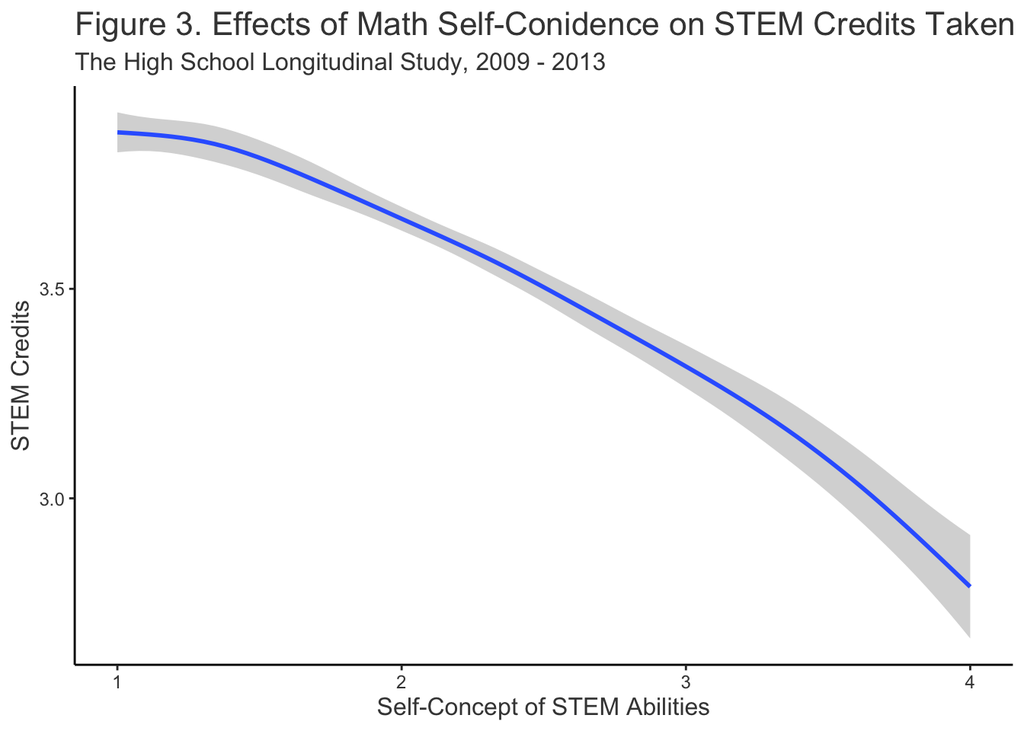

```r
# Include all code required to generate your visualization here.


ggplot(hwone) +
  geom_smooth(aes(x = self_concept_ability_math,
                  y = credits_stem))+
  scale_color_manual(values = "dodgerblue3")+
  labs(color = "Gender", title = "Figure 3. Effects of Math Self-Conidence on STEM Credits Taken by Gender", subtitle = "The High School Longitudinal Study, 2009 - 2013", y = "STEM Credits", x ="Self-Concept of STEM Abilities" )+
  theme_classic() +
  theme(axis.text.x = element_text(color = "gray26", size = 9),
        plot.title = element_text(color = "gray26", size = 16),
        plot.subtitle = element_text(color = "gray26", size =12),
        axis.text.y = element_text(color = "gray26", size = 9),
        axis.title.x = element_text(color = "gray26", size = 12),
        axis.title.y = element_text(color = "gray26", size = 12))
```

```r
ggsave("regression_cbivariate_stemcredits_assignment1.png")
```

# Comparative Bivariate Plot

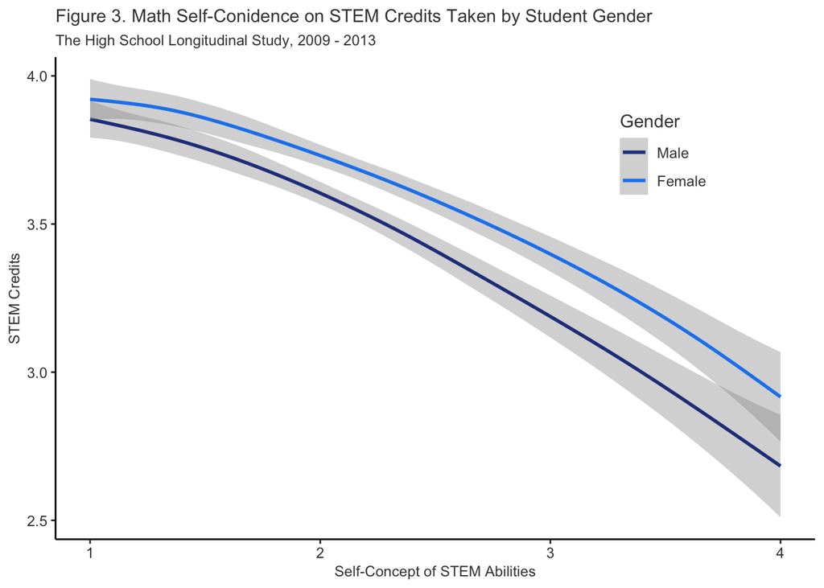

```r
# Include all code required to generate your visualization here.


ggplot(hwone) +
  geom_smooth(aes(x = self_concept_ability_math,
                  y = credits_stem,
                  color = factor(female,
                                 ordered = TRUE,
                                 levels = c(0,1),
                                 labels = c("Male","Female"))))+
  scale_color_manual(values = c("royalblue4","dodgerblue2"))+
  labs(color = "Gender", title = "Figure 3. Math Self-Conidence on STEM Credits Taken by Student Gender", subtitle = "The High School Longitudinal Study, 2009 - 2013", y = "STEM Credits", x ="Self-Concept of STEM Abilities" )+
  theme_classic() +
  theme(axis.text.x = element_text(color = "gray26", size = 9),
        plot.title = element_text(color = "gray26", size = 11),
        plot.subtitle = element_text(color = "gray26", size =9),
        axis.text.y = element_text(color = "gray26", size =9),
        axis.title.x = element_text(color = "gray26", size = 9),
        axis.title.y = element_text(color = "gray26", size = 9),
        legend.text = element_text(color = "gray26", size = 9),
        legend.title = element_text(color = "gray26"),
        legend.position = c(.8,.8))
```

```r
ggsave("regression_cbivariate_stemcredits_assignment1.png")
```

# Discussion

*Using your visualizations, address the research question. Be sure to discuss the design decisions you made in creating your visualizations and how they impact the appropriateness of your visualizations for answering the research question. Please refer to the evaluation criteria in the assignment description on Canvas.*

# Your own question

Now explore the other variables in this dataset and develop a question. Answer your question with data visualization.

```r
# Include all code required to generate your visualization here.

##cleaning data for first bivariate plot##
gpa_stem_adjusted2 <-replace(hwone$gpa_stem,hwone$gpa_stem<0,NA)

##cleaning data for second bivariate plot##
female_only <- hwone |> filter(female==1)


math_teacher_gender_adjusted <-replace(female_only$math_teacher_gender,female_only$math_teacher_gender>1,NA)

gpa_stem_adjusted <-replace(female_only$gpa_stem,female_only$gpa_stem<0,NA)
```

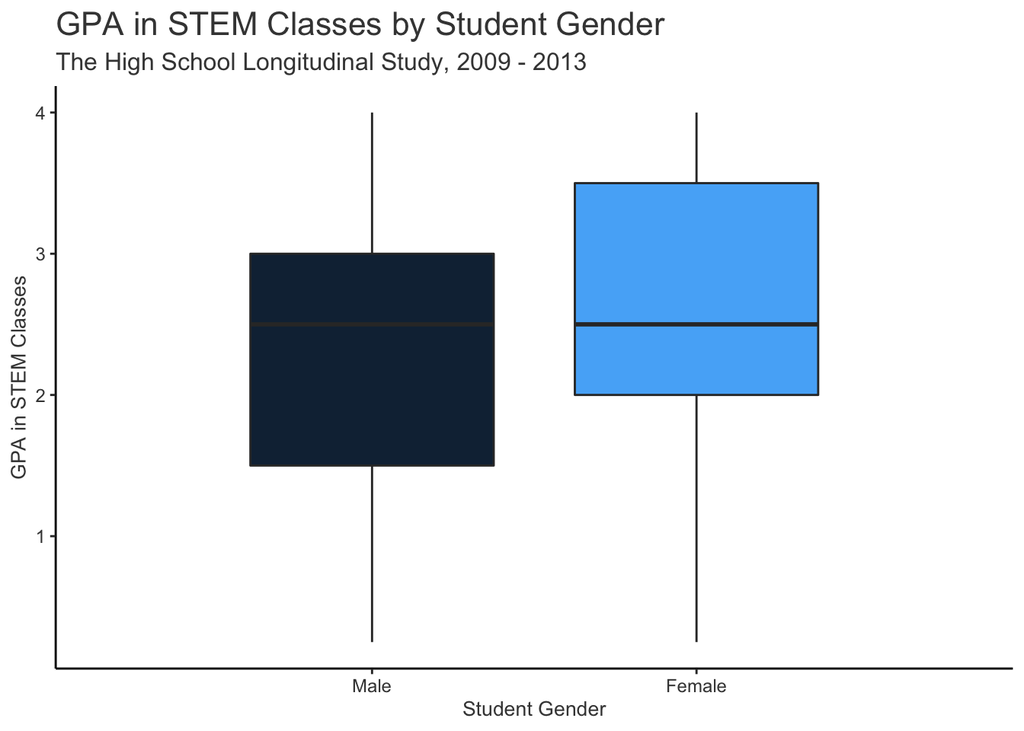

```r
ggplot(hwone) +
  geom_boxplot(aes(x = female,
                   group = factor(female,
                                  levels = c(0, 1),
                                  labels = c("Male", "Female")),
                    y = gpa_stem_adjusted2,
                    fill = female))+
    scale_x_discrete(limits = c(0,1), labels = c("Male","Female")) +
    labs(y = "GPA in STEM Classes", x = "Student Gender",
    title = "GPA in STEM Classes by Student Gender", subtitle = "The High School Longitudinal Study, 2009 - 2013") +
    theme_classic()+
    theme(legend.position = "none")+
    theme(axis.text.x = element_text(color = "gray26", size = 9),
          plot.title = element_text(color = "gray26", size = 16),
          plot.subtitle = element_text(color = "gray26", size =12),
          axis.text.y = element_text(color = "gray26", size =9),
          axis.title.x = element_text(color = "gray26", size = 10),
          axis.title.y = element_text(color = "gray26", size = 10))
```

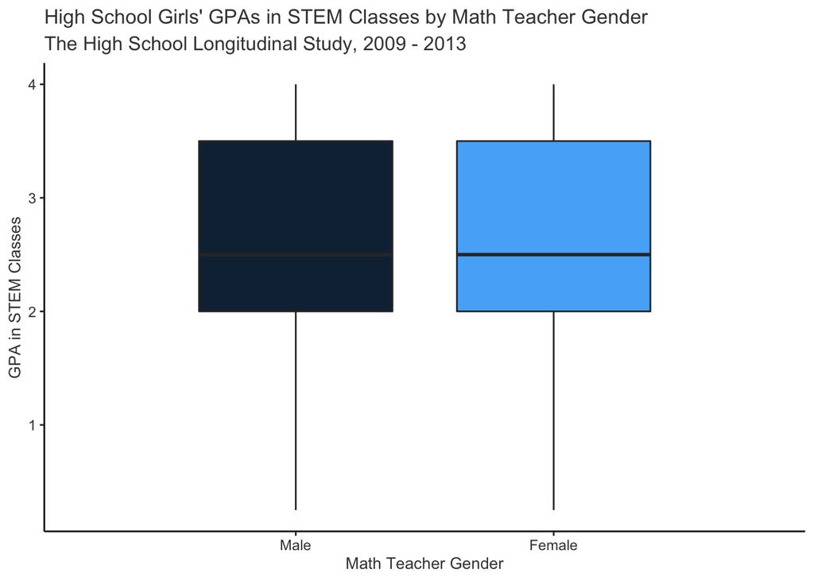

```r
ggplot(female_only) +
  geom_boxplot(aes(x = math_teacher_gender_adjusted,
                   group = factor(math_teacher_gender_adjusted,
                                  levels = c(0, 1, 3),
                                  labels = c("Male", "Female","Unknown")),
                    y = gpa_stem_adjusted,
                    fill = math_teacher_gender_adjusted))+
    scale_x_discrete(limits = c(0,1), labels = c("Male","Female")) +
    labs(y = "GPA in STEM Classes", x = "Math Teacher Gender", title = "High School Girls' GPAs in STEM Classes by Math Teacher Gender", subtitle = "The High School Longitudinal Study, 2009 - 2013") +
    theme_classic()+
    theme(legend.position = "none")+
    theme(axis.text.x = element_text(color = "gray26", size = 9),
          plot.title = element_text(color = "gray26", size = 12.4),
          plot.subtitle = element_text(color = "gray26", size =12),
          axis.text.y = element_text(color = "gray26", size =9),
          axis.title.x = element_text(color = "gray26", size = 10),
          axis.title.y = element_text(color = "gray26", size = 10))
```